# Differential Expression in OP42 and T89 Cambium

Nicolas Delhomme & Alok Ranjan

2017-08-08

# 1 Setup

# 2 Environment

Set the working dir

```r
setwd("/mnt/picea/projects/aspseq/cbellini/24_Bellini_cambium")
```

Libs

```r
suppressPackageStartupMessages(library(DESeq2))
suppressPackageStartupMessages(library(gplots))
suppressPackageStartupMessages(library(Glimma))
suppressPackageStartupMessages(library(RColorBrewer))
suppressPackageStartupMessages(library(LSD))
suppressPackageStartupMessages(library(VennDiagram))
```

Helper files

```r
source("~/Git/UPSCb/src/R/plotMA.R")
source("~/Git/UPSCb/src/R/volcanoPlot.R")
```

Load saved data

```r
load("analysis/DE-new/DESeqDataset-20170703.rda")
```

Setup graphics

```r
pal=brewer.pal(8,"Dark2")
hpal <- colorRampPalette(c("blue","white","red"))(100)
mar <- par("mar")
```

Cutoffs

```r
fdr <- 0.01
lfc <- 0.5
```

Annotation

```r
load("analysis/DE-new/annot.rda")
```

# 3 Process

## 3.1 VST

```r
vsd <- varianceStabilizingTransformation(dds, blind=FALSE)
vst <- assay(vsd)
vst <- vst - min(vst)
write.csv(vst,"analysis/HTSeq-new/library-size-normalized_variance-stabilized-model-aware_data.csv")
```

## 3.2 DE

Write a function

```r
"doDE" <- function(dds){

  # Model and compute statistics
  dds <- DESeq(dds)

  # Plot the dispersion estimation
  plotDispEsts(dds)

  # Get the results
  res <- results(dds)

  # number of DE genes at a 1% FDR and min 0.5 LFC (Log2 Fold Change)
  sel <- res$padj <= fdr & !is.na(res$padj) & abs(res$log2FoldChange) >= lfc
  tab <- table(sign(res[sel,"log2FoldChange"]))
  message(sprintf("There are %s genes that are DE, %s down, %s up",sum(sel),tab[1],tab[2]))

  # plot the MA and volcano plot
  volcanoPlot(res,alpha=fdr)

  # Return object
  return(list(res,res[sel,]))
}
```

## 3.3 Differential Expression

### 3.3.1 OP42 Time

```r
ddsOP42 <- dds[,grepl("OP",colnames(dds))]
design(ddsOP42) = ~Time
resOP42 <- doDE(ddsOP42)
```

```
## There are 5464 genes that are DE, 2222 down, 3242 up
```

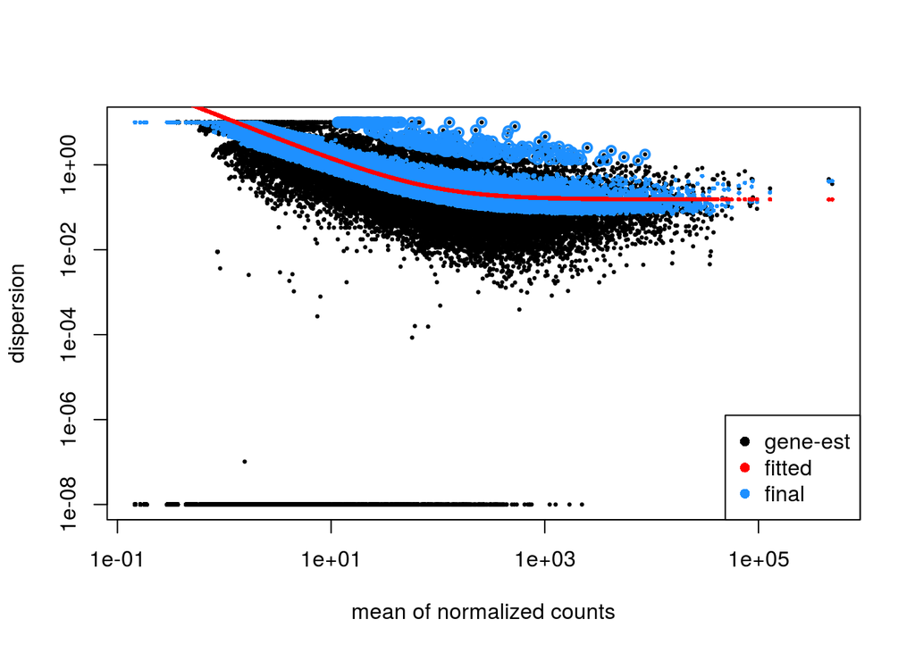

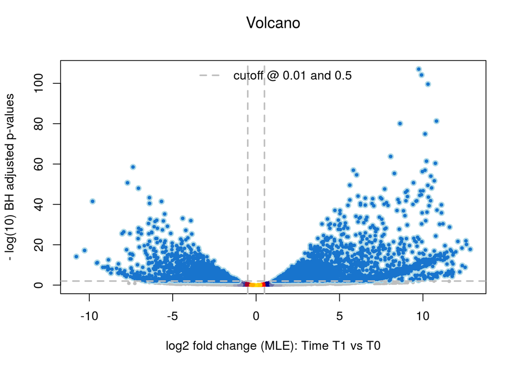

Write the results

```r
write.csv(resOP42[[1]],paste0("analysis/DE-new/OP42-T1-vs-T0-differential-expression_FDR",fdr,"-LFC",lfc,".csv"))
write.csv(resOP42[[2]],
          paste0("analysis/DE-new/OP42-T1-vs-T0-differential-expression_FDR",fdr,"-LFC",lfc,"-DE-only.csv"))
```

### 3.3.2 T89 Time

```r
ddsT89 <- dds[,grepl("T89",colnames(dds))]
design(ddsT89) = ~Time
```

We observe less DE genes in T89 compared to OP42. This is probably caused by the lack of one T0 replicate for T89. This makes DESeq2 more conservative as can be observed by comparing the volcanoplot of T89 and OP42.

```r
resT89 <- doDE(ddsT89)
```

```
## There are 1198 genes that are DE, 374 down, 824 up
```

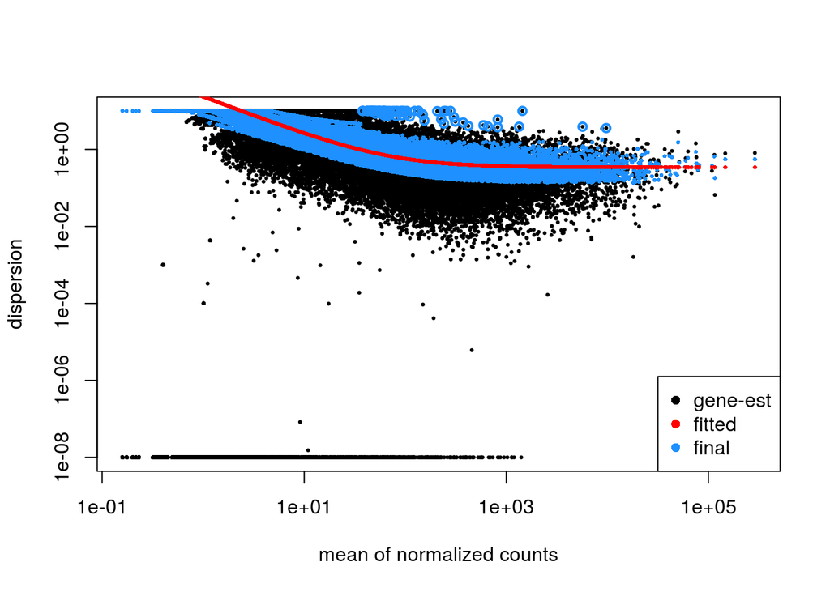

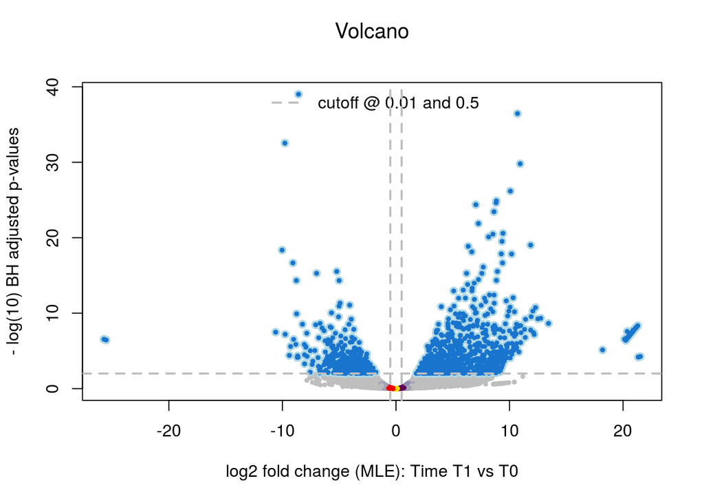

Write the results

```r
write.csv(resT89[[1]],paste0("analysis/DE-new/T89-T1-vs-T0-differential-expression_FDR",fdr,"-LFC",lfc,".csv"))
write.csv(resT89[[2]],
          paste0("analysis/DE-new/T89-T1-vs-T0-differential-expression_FDR",fdr,"-LFC",lfc,"-DE-only.csv"))
```

### 3.3.3 Compare the results

Plot the Venn diagram

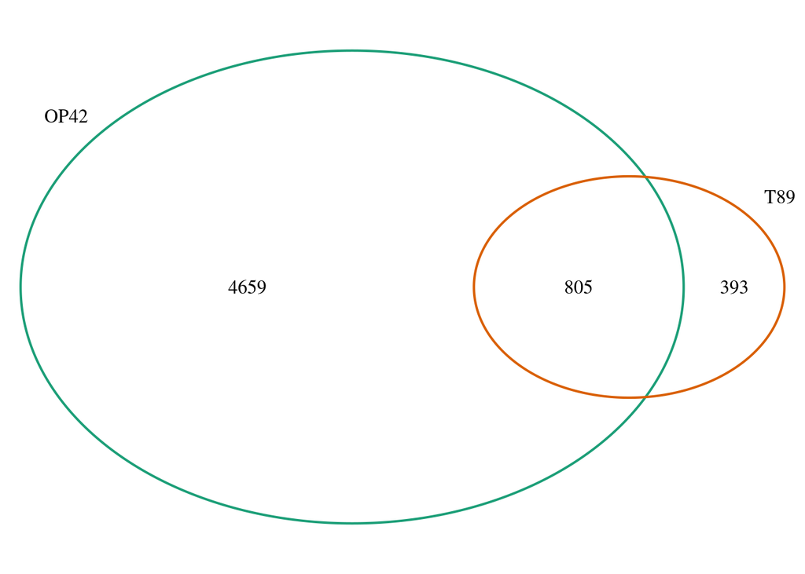

```r
DE.list <- list(OP42=rownames(resOP42[[2]]),
                  T89=rownames(resT89[[2]]))

plot.new()
grid.draw(venn.diagram(DE.list,
                       filename=NULL,
                       col=pal[1:length(DE.list)],
                       category.names=names(DE.list)))
```

## 3.4 DE Line (Species) + Time

```r
design(dds) <- ~Line + Time
```

We observe an almost similar number of gene differentially expressed as in OP42 when we block the line factor. This is a good indication that this approach would make sense to compare T1 vs T0 in a species-agnostic manner. It seems to indicate that the processes are conserved in both species.

```r
resLpT <- doDE(dds)
```

```
## There are 4800 genes that are DE, 1962 down, 2838 up
```

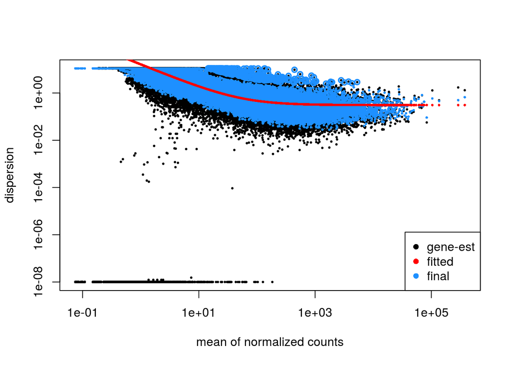

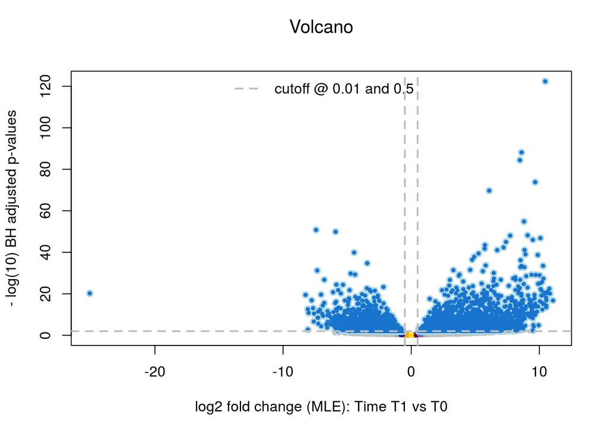

Write the results

```r
write.csv(resLpT[[1]],paste0("analysis/DE-new/Line-plus-Time-T1-vs-T0-differential-expression_FDR",fdr,"-LFC",lfc,".csv"))
write.csv(resLpT[[2]],paste0("analysis/DE-new/Line-plus-Time-T1-vs-T0-differential-expression_FDR",fdr,"-LFC",lfc,"-DE-only.csv"))
```

Create a Venn Diagram

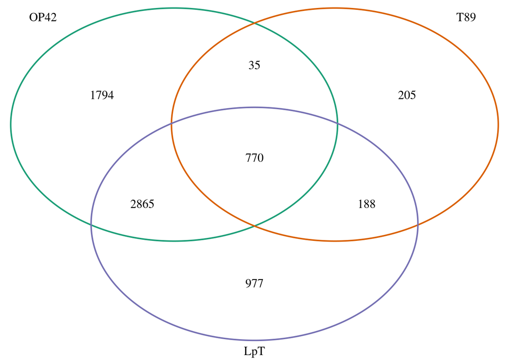

```r
DE.list <- list(OP42=rownames(resOP42[[2]]),
                T89=rownames(resT89[[2]]),
                LpT=rownames(resLpT[[2]]))
plot.new()
grid.draw(venn.diagram(DE.list,
                       filename=NULL,
                       col=pal[1:length(DE.list)],
                       category.names=names(DE.list)))
```

## 3.5 DE Species * Time

Almost the same as above, but instead of “discarding” the Line effect, we keep it and also look at the interaction between Line and Time. This assumes that the variables Line and Time are not independent.

```r
design(dds) <- ~Line*Time
ddsLbT <- DESeq(dds)
```

Plot the dispersion estimation

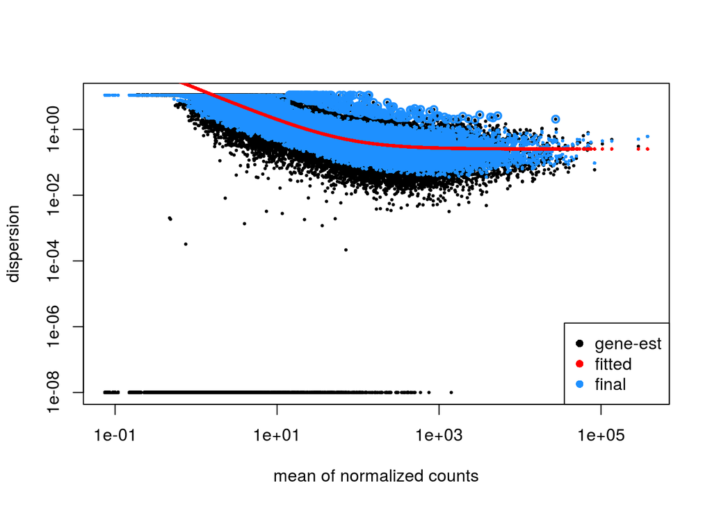

```r
plotDispEsts(ddsLbT)
```

Check what results are available

```r
resultsNames(ddsLbT)
```

```
## [1] "Intercept"        "Line_T89_vs_OP42" "Time_T1_vs_T0"
## [4] "LineT89.TimeT1"
```

### 3.5.1 Time effect different across Line

```r
resLbT <- results(ddsLbT,name = "LineT89.TimeT1")
sel <- resLbT$padj <= fdr & !is.na(resLbT$padj) & abs(resLbT$log2FoldChange) > lfc
tab <- table(sign(resLbT[sel,"log2FoldChange"]))
message(sprintf("There are %s genes that are DE, %s down, %s up",sum(sel),tab[1],tab[2]))
```

```
## There are 315 genes that are DE, 163 down, 152 up
```

Volcano plot

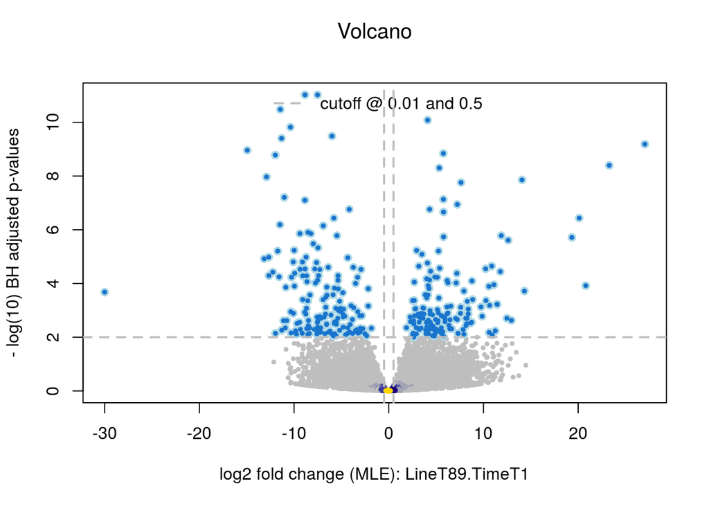

```r
volcanoPlot(resLbT,alpha=0.01)
```

Heatmap

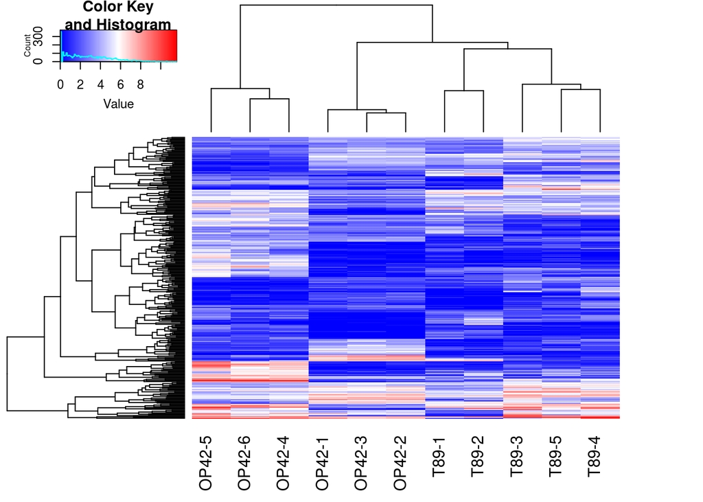

```r
stopifnot(all(rownames(resLbT) == rownames(vst)))
heatmap.2(as.matrix(vst[sel,]),trace="none",labRow=FALSE,col=hpal)
```

### 3.5.2 Interactive plot

```r
res.df <- as.data.frame(resLbT)
res.df$log10MeanNormCount <- log10(res.df$baseMean + 1)
idx <- rowSums(counts(ddsLbT)) > 0
res.df <- res.df[idx,]
res.df$padj[is.na(res.df$padj)] <- 1
sel <- !is.na(resLbT$padj) & resLbT$padj <= fdr & abs(resLbT$log2FoldChange) >= lfc
```

When exploring this report, it is essential to remember that the dot plot on the left contain values that have simply been corrected for their relative sequencing depth

```r
glMDPlot(res.df,
         xval = "log10MeanNormCount",
         yval = "log2FoldChange",
         counts = counts(ddsLbT)[idx,],
         anno = annot[idx,],
         groups = ddsLbT$LineTime,
         samples = ddsLbT$SampleName,
         status = as.integer(sel[idx]),
         display.columns = c("GeneID","synonyms","Description","genelist_atg_id"),
         id.column = "GeneID",
         path = "analysis/DE-new",
         folder = "report-Line-Time-Interaction-Term-differential-expression",
         launch=FALSE)
```

Write the results

```r
write.csv(resLbT,paste0("analysis/DE-new/Line-Time-Interaction-Term-differential-expression_FDR",fdr,"-LFC",lfc,".csv"))
write.csv(resLbT[sel,],paste0("analysis/DE-new/Line-Time-Interaction-Term-differential-expression_FDR",fdr,"-LFC",lfc,"-DE-only.csv"))
```

### 3.5.3 A look at the Line

I.e. looking at genes that are different between lines time independent

```r
resLine <- results(ddsLbT,name = "Line_T89_vs_OP42")
sel <- resLine$padj <= fdr & !is.na(resLine$padj) & abs(resLine$log2FoldChange) > lfc
tab <- table(sign(resLine[sel,"log2FoldChange"]))
message(sprintf("There are %s genes that are DE, %s down, %s up",sum(sel),tab[1],tab[2]))
```

```
## There are 2379 genes that are DE, 1354 down, 1025 up
```

Volcano plot

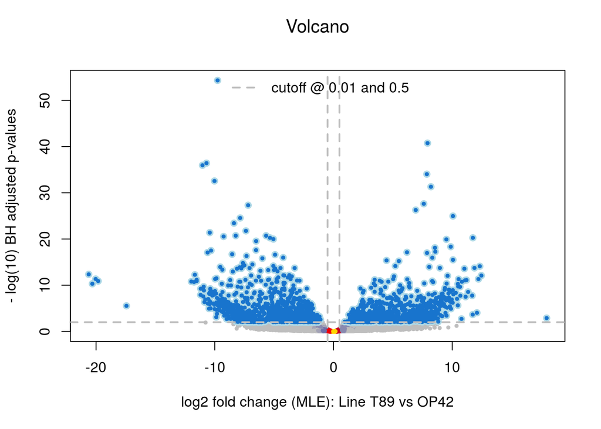

```r
volcanoPlot(resLine,alpha=0.01)
```

Heatmap

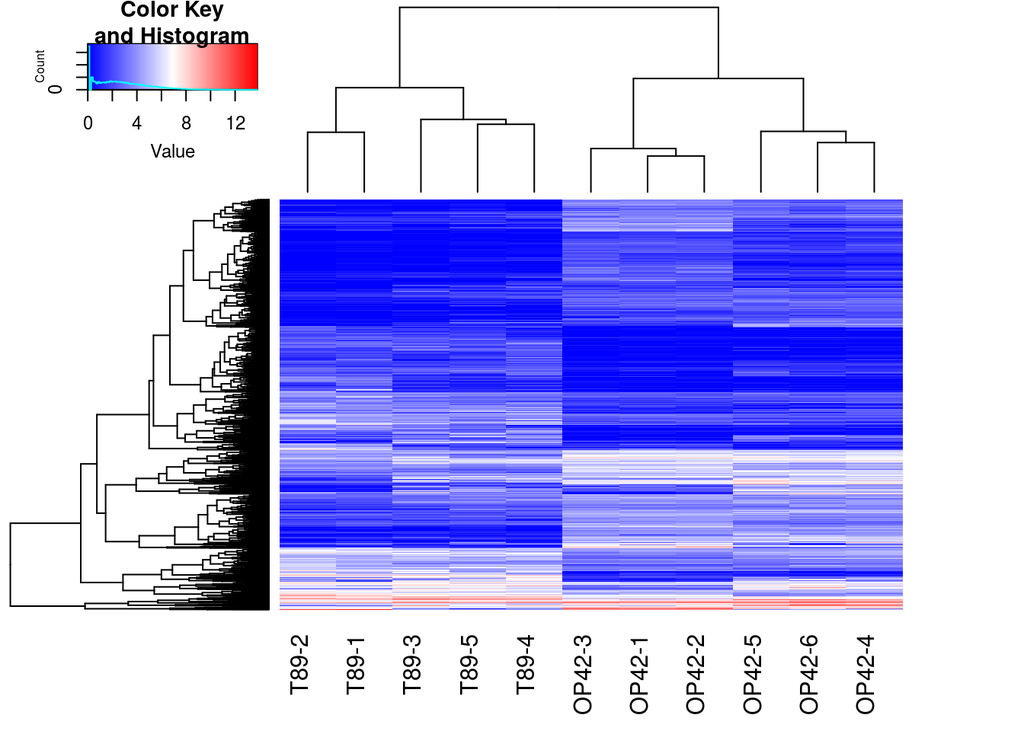

```r
heatmap.2(as.matrix(vst[sel,]),trace="none",labRow=FALSE,col=hpal)
```

### 3.5.4 Interactive plot

```r
res.df <- as.data.frame(resLine)
res.df$log10MeanNormCount <- log10(res.df$baseMean + 1)
idx <- rowSums(counts(ddsLbT)) > 0
res.df <- res.df[idx,]
res.df$padj[is.na(res.df$padj)] <- 1
sel <- !is.na(resLine$padj) & resLine$padj <= fdr & abs(resLine$log2FoldChange) >= lfc
```

When exploring this report, it is essential to remember that the dot plot on the left contain values that have simply been corrected for their relative sequencing depth

```r
glMDPlot(res.df,
         xval = "log10MeanNormCount",
         yval = "log2FoldChange",
         counts = counts(ddsLbT)[idx,],
         anno = annot[idx,],
         groups = ddsLbT$LineTime,
         samples = ddsLbT$SampleName,
         status = as.integer(sel[idx]),
         display.columns = c("GeneID","synonyms","Description","genelist_atg_id"),
         id.column = "GeneID",
         path = "analysis/DE-new",
         folder = "report-Line-Time_Line-effect_differential-expression",
         launch=FALSE)
```

Write the results

```r
write.csv(resLine,paste0("analysis/DE-new/Line-Time_Line-effect_differential-expression_FDR",fdr,"-LFC",lfc,".csv"))
write.csv(resLine[sel,],paste0("analysis/DE-new/Line-Time_Line-effect_differential-expression_FDR",fdr,"-LFC",lfc,"-DE-only.csv"))
```

### 3.5.5 A look at the Time

```r
resTime <- results(ddsLbT,name = "Time_T1_vs_T0")
sel <- resTime$padj <= fdr & !is.na(resTime$padj) & abs(resTime$log2FoldChange) > lfc
tab <- table(sign(resTime[sel,"log2FoldChange"]))
message(sprintf("There are %s genes that are DE, %s down, %s up",sum(sel),tab[1],tab[2]))
```

```
## There are 4013 genes that are DE, 1618 down, 2395 up
```

Volcano plot

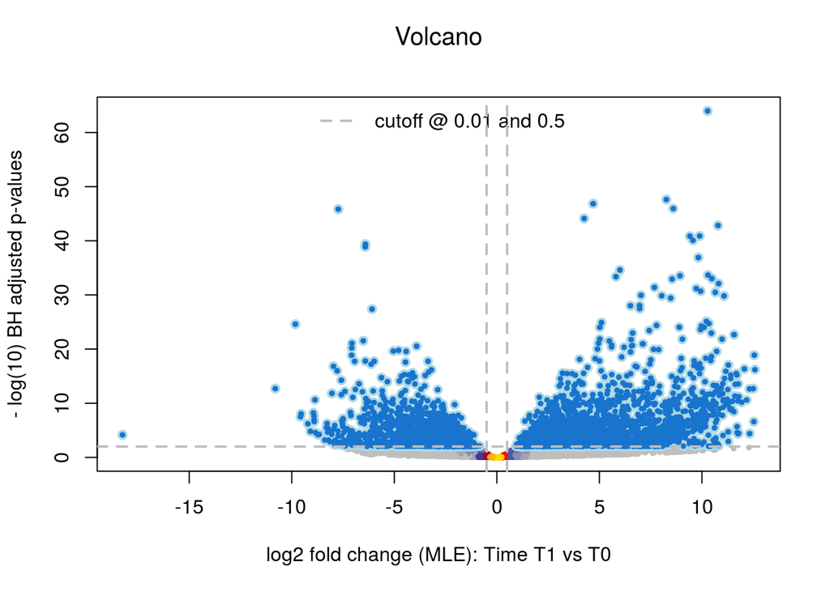

```r
volcanoPlot(resTime,alpha=0.01)
```

Heatmap

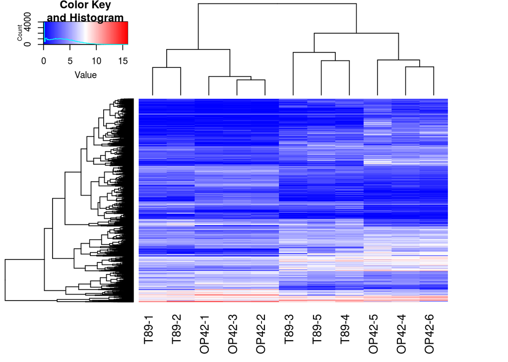

```r
heatmap.2(as.matrix(vst[sel,]),trace="none",labRow=FALSE,col=hpal)
```

### 3.5.6 Interactive plot

```r
res.df <- as.data.frame(resTime)
res.df$log10MeanNormCount <- log10(res.df$baseMean + 1)
idx <- rowSums(counts(ddsLbT)) > 0
res.df <- res.df[idx,]
res.df$padj[is.na(res.df$padj)] <- 1
sel <- !is.na(resTime$padj) & resTime$padj <= fdr & abs(resTime$log2FoldChange) >= lfc
```

When exploring this report, it is essential to remember that the dot plot on the left contain values that have simply been corrected for their relative sequencing depth

```r
glMDPlot(res.df,
         xval = "log10MeanNormCount",
         yval = "log2FoldChange",
         counts = counts(ddsLbT)[idx,],
         anno = annot[idx,],
         groups = ddsLbT$LineTime,
         samples = ddsLbT$SampleName,
         status = as.integer(sel[idx]),
         display.columns = c("GeneID","synonyms","Description","genelist_atg_id"),
         id.column = "GeneID",
         path = "analysis/DE-new",
         folder = "report-Line-Time_Time-effect_differential-expression",
         launch=FALSE)
```

Write the results

```r
write.csv(resTime,paste0("analysis/DE-new/Line-Time_Time-effect_differential-expression_FDR",fdr,"-LFC",lfc,".csv"))
write.csv(resTime[sel,],paste0("analysis/DE-new/Line-Time_Time-effect_differential-expression_FDR",fdr,"-LFC",lfc,"-DE-only.csv"))
```

## 3.6 Only Line

### 3.6.1 Setup T0

```r
ddsT0 <- dds[,grepl("T0",colData(dds)$Time)]
design(ddsT0) = ~Line
resT0 <- doDE(ddsT0)
```

```
## There are 4540 genes that are DE, 2533 down, 2007 up
```

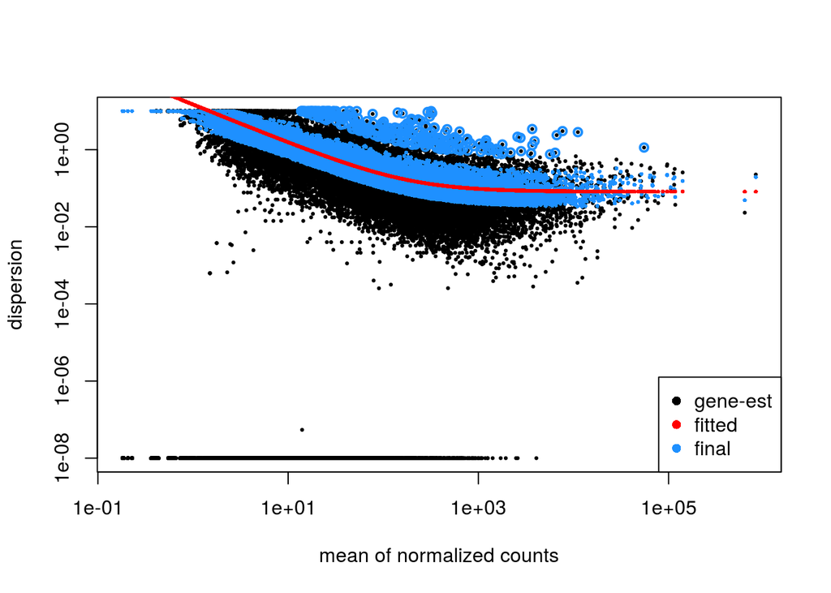

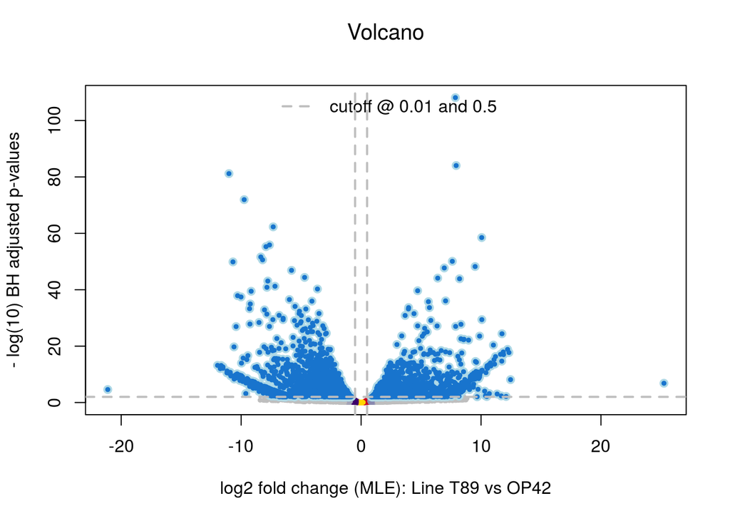

Write the results

```r
write.csv(resT0[[1]],paste0("analysis/DE-new/T0-T89-vs-OP42-differential-expression_FDR",fdr,"-LFC",lfc,".csv"))
write.csv(resT0[[2]],paste0("analysis/DE-new/T0-T89-vs-OP42-differential-expression_FDR",fdr,"-LFC",lfc,"-DE-only.csv"))
```

### 3.6.2 Setup T1

```r
ddsT1 <- dds[,grepl("T1",colData(dds)$Time)]
design(ddsT1) = ~Line
resT1 <- doDE(ddsT1)
```

```
## There are 2486 genes that are DE, 1330 down, 1156 up
```

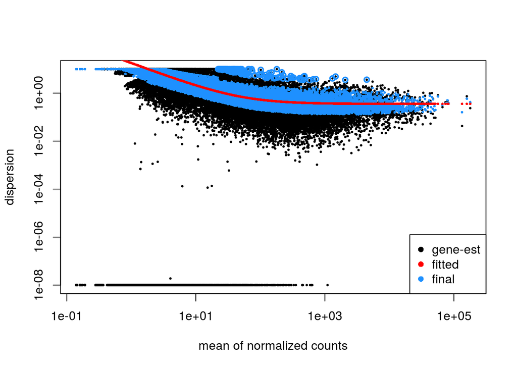

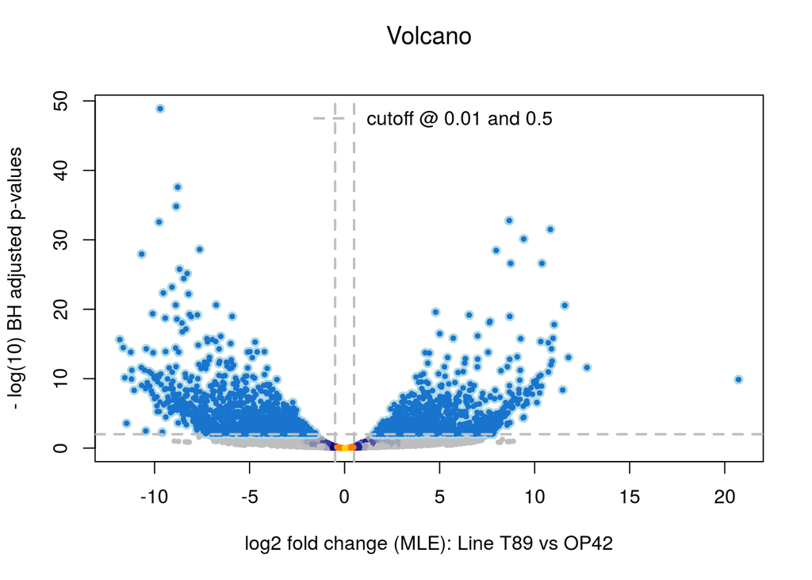

Write the results

```r
write.csv(resT1[[1]],paste0("analysis/DE-new/T1-T89-vs-OP42-differential-expression_FDR",fdr,"-LFC",lfc,".csv"))
write.csv(resT1[[2]],paste0("analysis/DE-new/T1-T89-vs-OP42-differential-expression_FDR",fdr,"-LFC",lfc,"-DE-only.csv"))
```